# HPCC

nikolays

07/14/21

# Metrics

Some of reported HPCC metrics:

- Average Double-Precision General Matrix Multiplication (DGEMM) Floating-Point Performance
  - Embarrassingly parallel, Averaged over all MPI process, MFLOP per Second per MPI process
  - (There is also serial metric; measured but not analysed)
- High Performance LINPACK Floating-Point Performance
  - Parallel, overall MFLOP per Second
- Fast Fourier Transform (FFTW) Floating-Point Performance
  - Parallel, MFLOP per Second
  - (There are also serial and embarrassingly parallel metrics; measured but not analysed)
- Parallel Matrix Transpose (PTRANS)
  - Parallel, overall MByte per Second
- MPI Random Access
  - Parallel, overall MUpdate per Second
  - (There are also serial and embarrassingly parallel metrics; measured but not analysed)
- Average STREAM ‘Triad’/ ‘Add’ / ‘Copy’ / ‘Scale’ Memory Bandwidth
  - Embarrassingly parallel, Averaged over all MPI process, MByte per Second
  - (There is also serial metric; measured but not analysed)

# Results

## Selected metrics

### DGEMM

| config | average | stdev | tflops | label |
| --- | --- | --- | --- | --- |
| Bridges-2(AMD Zen2); OpenBlas | 23.019437 | 0.423738634 | 36.0 | 23 (63.9%) |
| Expanse(AMD Zen2); OpenBlas | 25.259362 | 0.222667377 | 36.0 | 25.3 (70.2%) |
| Ookami; ARMPL | 34.591105 | 0.852785333 | 57.6 | 34.6 (60.1%) |
| Ookami; LibSci(Cray)) | 19.960305 | 0.010477267 | 57.6 | 20 (34.7%) |
| Ookami; Fujitsu | 40.911100 | 0.492255636 | 57.6 | 40.9 (71%) |
| Ookami; OpenBlas | 2.950611 | 0.006788939 | 57.6 | 3 (5.1%) |
| Stampede-2(Intel KNL); MKL | 5.024615 | 0.252011734 | 44.8 | 5 (11.2%) |
| Stampede-2(Intel SKX); MKL | 43.416170 | 2.258866075 | 44.8 | 43.4 (96.9%) |

### HPL

| config | nodes | cores | average | stdev | tflops | label |
| --- | --- | --- | --- | --- | --- | --- |
| Bridges-2(AMD Zen2); OpenBlas | 1 | 128 | 1911.3015 | 144.024251 | 4608.0 | 1911 (41.5%) |
| Expanse(AMD Zen2); OpenBlas | 1 | 128 | 1732.8653 | 21.122932 | 4608.0 | 1733 (37.6%) |
| Ookami; ARMPL | 1 | 48 | 535.7956 | 16.617003 | 2764.8 | 536 (19.4%) |
| Ookami; LibSci(Cray)) | 1 | 48 | 779.8320 | 16.347201 | 2764.8 | 780 (28.2%) |
| Ookami; Fujitsu | 1 | 48 | 1128.8186 | 63.364961 | 2764.8 | 1129 (40.8%) |
| Ookami; OpenBlas | 1 | 48 | 115.0379 | 1.338839 | 2764.8 | 115 (4.2%) |
| Stampede-2(Intel KNL); MKL | 1 | 68 | 991.5951 | 14.817496 | 3046.4 | 992 (32.5%) |
| Stampede-2(Intel SKX); MKL | 1 | 48 | 1155.7845 | 31.095480 | 2150.4 | 1156 (53.7%) |

[figure not shown]

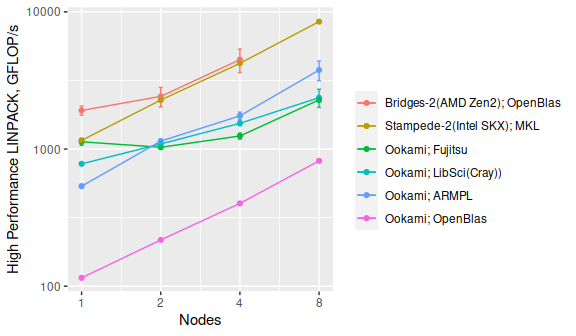

### FFT

| config | nodes | cores | average | stdev | tflops | label |
| --- | --- | --- | --- | --- | --- | --- |
| Bridges-2(AMD Zen2); FFTW2 | 1 | 128 | 47.6859265 | 9.62661870 | 4608.0 | 47.69 (1.03%) |
| Expanse(AMD Zen2); FFTW3 | 1 | 128 | 72.2328225 | 2.14722742 | 4608.0 | 72.23 (1.57%) |
| Ookami; ARMPL | 1 | 48 | 0.2645411 | 0.02067933 | 2764.8 | 0.26 (0.01%) |
| Ookami; FFTW3-Cray | 1 | 48 | 21.7243300 | 0.83729301 | 2764.8 | 21.72 (0.79%) |
| Ookami; FFTW3-Fujitsu | 1 | 48 | 24.9762250 | 0.25313684 | 2764.8 | 24.98 (0.9%) |
| Ookami; FFTW3 | 1 | 48 | 5.8354770 | 0.66527075 | 2764.8 | 5.84 (0.21%) |
| Stampede-2(Intel KNL); MKL | 1 | 68 | 45.9546925 | 1.09085136 | 3046.4 | 45.95 (1.51%) |
| Stampede-2(Intel SKX); MKL | 1 | 48 | 42.8901250 | 0.35557409 | 2150.4 | 42.89 (1.99%) |

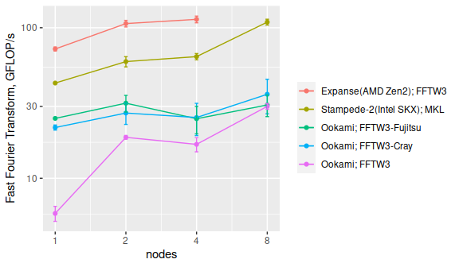

[figure not shown]

### STREAM

[figure not shown]

## Overall Performance (That is per All MPI Processes)

### High Performance LINPACK Floating-Point Performance, MFLOP per Second

High Performance LINPACK Floating-Point Performance, MFLOP per Second

| config | cores | average | stdev |
| --- | --- | --- | --- |
| Ookami; ARM | 48 | 535795.6 | 16617.00 |
| Ookami; ARM | 96 | 1142335.0 | 37882.68 |
| Ookami; ARM | 192 | 1745858.0 | 111047.13 |
| Ookami; ARM | 384 | 3767065.5 | 614495.34 |
| Ookami; Cray | 48 | 779832.0 | 16347.20 |
| Ookami; Cray | 96 | 1088896.6 | 47401.35 |
| Ookami; Cray | 192 | 1540463.0 | 59648.31 |
| Ookami; Cray | 384 | 2367677.5 | 359084.13 |
| Ookami; cray,libsci,fftw-cray,mvapich | 48 | 798412.2 | 5841.94 |
| Ookami; cray,libsci,fftw-cray,mvapich | 96 | 1170094.0 | 8101.97 |
| Ookami; cray,libsci,fftw-cray,mvapich | 192 | 1636268.0 | 38642.51 |
| Ookami; cray,libsci,fftw-cray,mvapich | 384 | 2730327.8 | 122638.49 |
| Ookami; cray,libsci,fftw-cray,mvapich | 768 | 3960172.2 | 260851.89 |
| Ookami; Fujitsu | 48 | 1128818.6 | 63364.96 |
| Ookami; Fujitsu | 96 | 1029954.6 | 27195.92 |
| Ookami; Fujitsu | 192 | 1244959.0 | 61863.83 |
| Ookami; Fujitsu | 384 | 2282040.0 | 80628.08 |
| Ookami; gcc,armpl,mvapich | 48 | 969092.4 | 10208.34 |
| Ookami; gcc,armpl,mvapich | 96 | 1310979.1 | 76321.64 |
| Ookami; gcc,armpl,mvapich | 192 | 1701196.4 | 62641.53 |
| Ookami; gcc,openblas,fftw-rd,mvapich | 48 | 121724.3 | 826.64 |
| Ookami; gcc,openblas,fftw-rd,mvapich | 96 | 231342.1 | 3580.44 |
| Ookami; gcc,openblas,fftw-rd,mvapich | 192 | 416138.4 | 3251.73 |
| Ookami; OSS | 48 | 115037.9 | 1338.84 |
| Ookami; OSS | 96 | 217453.8 | 4233.92 |
| Ookami; OSS | 192 | 401580.3 | 8209.82 |
| Ookami; OSS | 384 | 820264.3 | 24845.10 |
| Ookami; OSSFE | 48 | 117490.1 | 770.92 |
| Ookami; OSSFE | 96 | 220139.8 | 24076.70 |
| Ookami; OSSFE | 192 | 420287.2 | 20553.65 |
| Ookami; OSSFE | 384 | 873566.2 | 31332.78 |
| Stampede2-SKX; icc,mkl,intel-mpi | 48 | 1136890.9 | 32875.98 |
| Stampede2-SKX; icc,mkl,intel-mpi | 96 | 2245493.6 | 38268.88 |
| Stampede2-SKX; icc,mkl,intel-mpi | 192 | 4214315.0 | 80665.64 |
| Stampede2-SKX; icc,mkl,intel-mpi | 384 | 8479441.0 | 102739.62 |
| Stampede2-SKX; icc,mkl,intel-mpi | 768 | 15933200.0 | NA |

### Fast Fourier Transform (FFTW) Floating-Point Performance, MFLOP per Second

Fast Fourier Transform (FFTW) Floating-Point Performance, MFLOP per Second

| config | cores | average | stdev |
| --- | --- | --- | --- |
| Ookami; ARM | 48 | 264.54 | 20.68 |
| Ookami; ARM | 96 | 247.57 | 17.25 |
| Ookami; ARM | 192 | 233.69 | 2.62 |
| Ookami; ARM | 384 | 224.83 | 6.72 |
| Ookami; Cray | 48 | 21724.33 | 837.29 |
| Ookami; Cray | 96 | 27107.15 | 4332.70 |
| Ookami; Cray | 192 | 25316.80 | 6122.87 |
| Ookami; Cray | 384 | 36117.96 | 9333.72 |
| Ookami; cray,libsci,fftw-cray,mvapich | 48 | 21841.60 | 444.98 |
| Ookami; cray,libsci,fftw-cray,mvapich | 96 | 26190.35 | 3764.05 |
| Ookami; cray,libsci,fftw-cray,mvapich | 192 | 33631.62 | 1905.40 |
| Ookami; cray,libsci,fftw-cray,mvapich | 384 | 41834.94 | 1996.65 |
| Ookami; cray,libsci,fftw-cray,mvapich | 768 | 73214.14 | 9931.32 |
| Ookami; Fujitsu | 48 | 24976.22 | 253.14 |
| Ookami; Fujitsu | 96 | 31516.62 | 3997.96 |
| Ookami; Fujitsu | 192 | 24852.59 | 5141.80 |
| Ookami; Fujitsu | 384 | 30668.63 | 5001.21 |
| Ookami; gcc,armpl,mvapich | 48 | 297.69 | 7.64 |
| Ookami; gcc,armpl,mvapich | 96 | 254.19 | 7.51 |
| Ookami; gcc,armpl,mvapich | 192 | 198.87 | 18.58 |
| Ookami; gcc,openblas,fftw-3.3.9,openmpi | 48 | 5804.66 | 606.83 |
| Ookami; gcc,openblas,fftw-fujitsu,openmpi | 48 | 25750.45 | 2785.65 |
| Ookami; gcc,openblas,fftw-rd,mvapich | 48 | 22525.90 | 1073.28 |
| Ookami; gcc,openblas,fftw-rd,mvapich | 96 | 34312.05 | 796.50 |
| Ookami; gcc,openblas,fftw-rd,mvapich | 192 | 34377.85 | 1404.21 |
| Ookami; OSS | 48 | 5835.48 | 665.27 |
| Ookami; OSS | 96 | 18685.22 | 534.33 |
| Ookami; OSS | 192 | 16788.10 | 1813.59 |
| Ookami; OSS | 384 | 30026.87 | 1306.53 |
| Ookami; OSSFE | 48 | 26437.04 | 2855.71 |
| Ookami; OSSFE | 96 | 36491.82 | 968.50 |
| Ookami; OSSFE | 192 | 30554.68 | 5545.47 |
| Ookami; OSSFE | 384 | 46758.82 | 818.15 |
| Stampede2-SKX; icc,mkl,intel-mpi | 48 | 41157.64 | 1360.57 |
| Stampede2-SKX; icc,mkl,intel-mpi | 96 | 57192.03 | 4177.13 |
| Stampede2-SKX; icc,mkl,intel-mpi | 192 | 63627.05 | 5168.34 |
| Stampede2-SKX; icc,mkl,intel-mpi | 384 | 110116.93 | 4665.70 |
| Stampede2-SKX; icc,mkl,intel-mpi | 768 | 198047.00 | NA |

### Parallel Matrix Transpose (PTRANS), MByte per Second

Parallel Matrix Transpose (PTRANS), MByte per Second

| config | cores | average | stdev |
| --- | --- | --- | --- |
| Ookami; ARM | 48 | 16432.01 | 4935.29 |
| Ookami; ARM | 96 | 24134.72 | 2622.38 |
| Ookami; ARM | 192 | 34749.34 | 3960.13 |
| Ookami; ARM | 384 | 50760.66 | 6545.82 |
| Ookami; Cray | 48 | 19130.78 | 5371.91 |
| Ookami; Cray | 96 | 16563.23 | 1634.73 |
| Ookami; Cray | 192 | 21945.69 | 6772.61 |
| Ookami; Cray | 384 | 24475.92 | 6564.58 |
| Ookami; cray,libsci,fftw-cray,mvapich | 48 | 21924.53 | 300.81 |
| Ookami; cray,libsci,fftw-cray,mvapich | 96 | 16241.23 | 698.59 |
| Ookami; cray,libsci,fftw-cray,mvapich | 192 | 31591.13 | 1156.06 |
| Ookami; cray,libsci,fftw-cray,mvapich | 384 | 27979.91 | 951.00 |
| Ookami; cray,libsci,fftw-cray,mvapich | 768 | 40842.54 | 2958.71 |
| Ookami; Fujitsu | 48 | 15557.92 | 164.88 |
| Ookami; Fujitsu | 96 | 13618.98 | 2201.59 |
| Ookami; Fujitsu | 192 | 20332.59 | 3085.36 |
| Ookami; Fujitsu | 384 | 30598.85 | 4132.68 |
| Ookami; gcc,armpl,mvapich | 48 | 22332.35 | 1527.83 |
| Ookami; gcc,armpl,mvapich | 96 | 23394.42 | 1652.13 |
| Ookami; gcc,armpl,mvapich | 192 | 29065.72 | 4013.39 |
| Ookami; gcc,openblas,fftw-rd,mvapich | 48 | 20993.82 | 4074.78 |
| Ookami; gcc,openblas,fftw-rd,mvapich | 96 | 25365.94 | 926.88 |
| Ookami; gcc,openblas,fftw-rd,mvapich | 192 | 27290.27 | 3658.27 |
| Ookami; OSS | 48 | 16276.32 | 3845.24 |
| Ookami; OSS | 96 | 21372.36 | 5829.93 |
| Ookami; OSS | 192 | 32942.72 | 8885.45 |
| Ookami; OSS | 384 | 49853.51 | 11255.22 |
| Ookami; OSSFE | 48 | 19316.54 | 2553.50 |
| Ookami; OSSFE | 96 | 24564.68 | 5150.44 |
| Ookami; OSSFE | 192 | 33272.92 | 7916.83 |
| Ookami; OSSFE | 384 | 55469.38 | 9926.15 |
| Stampede2-SKX; icc,mkl,intel-mpi | 48 | 14774.64 | 258.69 |
| Stampede2-SKX; icc,mkl,intel-mpi | 96 | 26250.93 | 1939.42 |
| Stampede2-SKX; icc,mkl,intel-mpi | 192 | 41518.02 | 3998.56 |
| Stampede2-SKX; icc,mkl,intel-mpi | 384 | 60789.69 | 1352.06 |
| Stampede2-SKX; icc,mkl,intel-mpi | 768 | 112281.60 | NA |

### MPI Random Access, MUpdate per Second

MPI Random Access, MUpdate per Second

| config | cores | average | stdev |
| --- | --- | --- | --- |
| Ookami; ARM | 48 | 85.28 | 2.67 |
| Ookami; ARM | 96 | 70.79 | 3.11 |
| Ookami; ARM | 192 | 49.41 | 3.39 |
| Ookami; ARM | 384 | 52.90 | 3.88 |
| Ookami; Cray | 48 | 14.07 | 0.17 |
| Ookami; Cray | 96 | 4.14 | 0.08 |
| Ookami; Cray | 192 | 2.95 | 0.12 |
| Ookami; Cray | 384 | 2.98 | 0.99 |
| Ookami; cray,libsci,fftw-cray,mvapich | 48 | 14.14 | 0.07 |
| Ookami; cray,libsci,fftw-cray,mvapich | 96 | 4.17 | 0.07 |
| Ookami; cray,libsci,fftw-cray,mvapich | 192 | 2.95 | 0.13 |
| Ookami; cray,libsci,fftw-cray,mvapich | 384 | 3.62 | 0.25 |
| Ookami; cray,libsci,fftw-cray,mvapich | 768 | 5.51 | 0.50 |
| Ookami; Fujitsu | 48 | 19.19 | 1.07 |
| Ookami; Fujitsu | 96 | 36.55 | 1.57 |
| Ookami; Fujitsu | 192 | 29.99 | 1.08 |
| Ookami; Fujitsu | 384 | 18.81 | 0.36 |
| Ookami; gcc,armpl,mvapich | 48 | 14.18 | 0.06 |
| Ookami; gcc,armpl,mvapich | 96 | 4.23 | 0.07 |
| Ookami; gcc,armpl,mvapich | 192 | 3.09 | 0.13 |
| Ookami; gcc,openblas,fftw-rd,mvapich | 48 | 14.51 | 0.09 |
| Ookami; gcc,openblas,fftw-rd,mvapich | 96 | 4.15 | 0.08 |
| Ookami; gcc,openblas,fftw-rd,mvapich | 192 | 3.01 | 0.09 |
| Ookami; OSS | 48 | 86.77 | 2.01 |
| Ookami; OSS | 96 | 69.45 | 4.38 |
| Ookami; OSS | 192 | 49.50 | 3.36 |
| Ookami; OSS | 384 | 52.70 | 2.34 |
| Ookami; OSSFE | 48 | 79.82 | 3.61 |
| Ookami; OSSFE | 96 | 64.10 | 13.72 |
| Ookami; OSSFE | 192 | 46.90 | 3.56 |
| Ookami; OSSFE | 384 | 51.52 | 3.00 |
| Stampede2-SKX; icc,mkl,intel-mpi | 48 | 39.34 | 0.38 |
| Stampede2-SKX; icc,mkl,intel-mpi | 96 | 72.73 | 0.89 |
| Stampede2-SKX; icc,mkl,intel-mpi | 192 | 129.63 | 1.12 |
| Stampede2-SKX; icc,mkl,intel-mpi | 384 | 197.66 | 5.15 |
| Stampede2-SKX; icc,mkl,intel-mpi | 768 | 300.36 | NA |

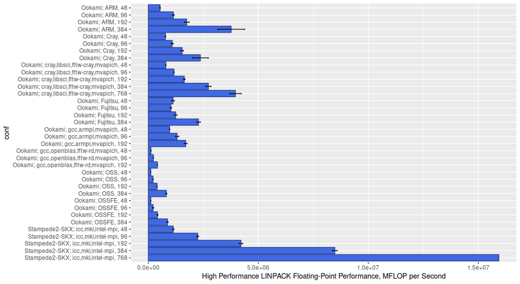

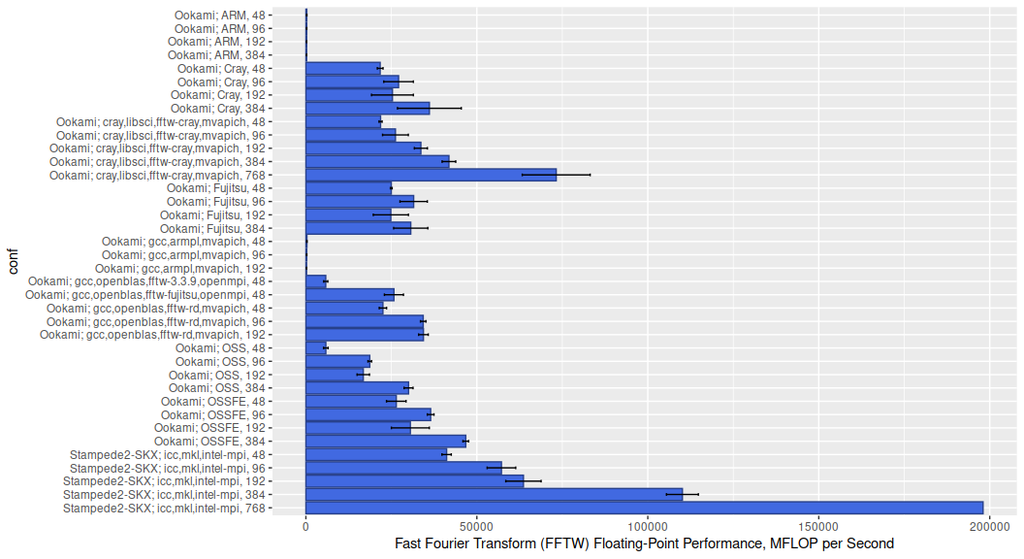

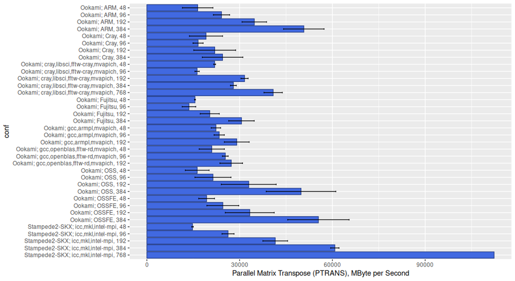

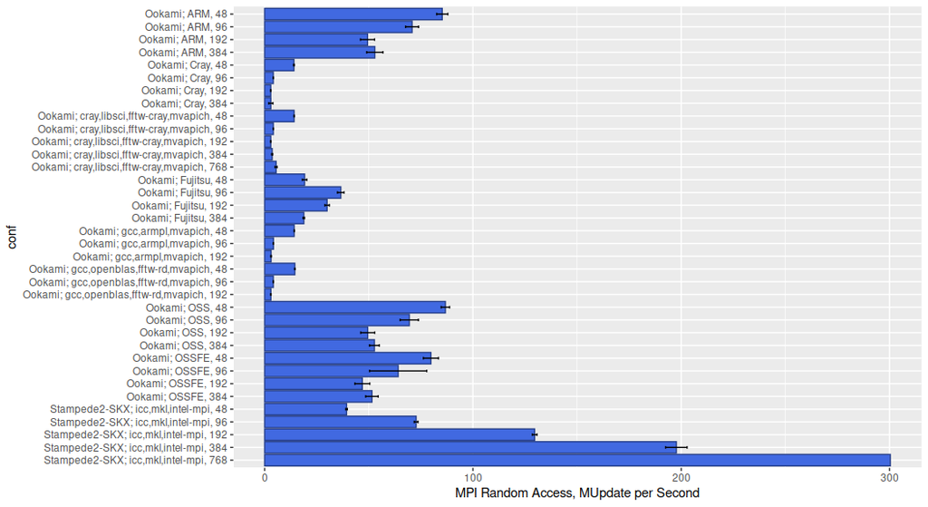

### Average Double-Precision General Matrix Multiplication (DGEMM) Floating-Point Performance, MFLOP per Second

Average Double-Precision General Matrix Multiplication (DGEMM) Floating-Point Performance, MFLOP per Second

| config | cores | average | stdev |
| --- | --- | --- | --- |
| Ookami; ARM | 48 | 1660373.0 | 40933.70 |
| Ookami; ARM | 96 | 3296314.1 | 162904.30 |
| Ookami; ARM | 192 | 6578523.8 | 307121.46 |
| Ookami; ARM | 384 | 12957596.2 | 712621.70 |
| Ookami; Cray | 48 | 958094.6 | 502.91 |
| Ookami; Cray | 96 | 1916234.4 | 5393.32 |
| Ookami; Cray | 192 | 3827705.3 | 42847.17 |
| Ookami; Cray | 384 | 7458889.0 | 295953.32 |
| Ookami; cray,libsci,fftw-cray,mvapich | 48 | 957623.0 | 215.99 |
| Ookami; cray,libsci,fftw-cray,mvapich | 96 | 1915288.3 | 448.16 |
| Ookami; cray,libsci,fftw-cray,mvapich | 192 | 3829407.4 | 2376.46 |
| Ookami; cray,libsci,fftw-cray,mvapich | 384 | 7662080.0 | 1103.96 |
| Ookami; cray,libsci,fftw-cray,mvapich | 768 | 15328520.5 | 15656.11 |
| Ookami; Fujitsu | 48 | 1963732.8 | 23628.27 |
| Ookami; Fujitsu | 96 | 3945349.0 | 4093.82 |
| Ookami; Fujitsu | 192 | 7881528.0 | 12487.65 |
| Ookami; Fujitsu | 384 | 15690543.4 | 230414.87 |
| Ookami; gcc,armpl,mvapich | 48 | 1584897.2 | 39365.73 |
| Ookami; gcc,armpl,mvapich | 96 | 3147560.7 | 87734.41 |
| Ookami; gcc,armpl,mvapich | 192 | 6469176.4 | 153449.66 |
| Ookami; gcc,openblas,fftw-rd,mvapich | 48 | 141221.6 | 831.20 |
| Ookami; gcc,openblas,fftw-rd,mvapich | 96 | 284081.2 | 91.22 |
| Ookami; gcc,openblas,fftw-rd,mvapich | 192 | 567925.2 | 329.78 |
| Ookami; OSS | 48 | 141629.3 | 325.87 |
| Ookami; OSS | 96 | 282382.6 | 1418.73 |
| Ookami; OSS | 192 | 566752.9 | 1185.74 |
| Ookami; OSS | 384 | 1127237.0 | 7835.27 |
| Ookami; OSSFE | 48 | 141517.3 | 190.78 |
| Ookami; OSSFE | 96 | 283386.6 | 868.25 |
| Ookami; OSSFE | 192 | 565341.0 | 3317.55 |
| Ookami; OSSFE | 384 | 1132909.1 | 3733.26 |
| Stampede2-SKX; icc,mkl,intel-mpi | 48 | 2143204.8 | 57346.26 |
| Stampede2-SKX; icc,mkl,intel-mpi | 96 | 4117100.5 | 114732.72 |
| Stampede2-SKX; icc,mkl,intel-mpi | 192 | 8202844.8 | 122461.53 |
| Stampede2-SKX; icc,mkl,intel-mpi | 384 | 16244382.7 | 173185.84 |
| Stampede2-SKX; icc,mkl,intel-mpi | 768 | 32680857.6 | NA |

### Average STREAM ‘Triad’ Memory Bandwidth, MByte per Second

Average STREAM ‘Triad’ Memory Bandwidth, MByte per Second

| config | cores | average | stdev |
| --- | --- | --- | --- |
| Ookami; ARM | 48 | 558740.4 | 85402.28 |
| Ookami; ARM | 96 | 1228548.3 | 63154.19 |
| Ookami; ARM | 192 | 2777841.0 | 1355896.62 |
| Ookami; ARM | 384 | 5013340.8 | 389184.67 |
| Ookami; Cray | 48 | 642580.1 | 16080.91 |
| Ookami; Cray | 96 | 1262820.3 | 147632.57 |
| Ookami; Cray | 192 | 2723201.8 | 970575.29 |
| Ookami; Cray | 384 | 4634609.3 | 1674804.83 |
| Ookami; cray,libsci,fftw-cray,mvapich | 48 | 645333.8 | 1154.26 |
| Ookami; cray,libsci,fftw-cray,mvapich | 96 | 1282324.6 | 8296.91 |
| Ookami; cray,libsci,fftw-cray,mvapich | 192 | 2518920.1 | 9364.26 |
| Ookami; cray,libsci,fftw-cray,mvapich | 384 | 4922177.4 | 42885.82 |
| Ookami; cray,libsci,fftw-cray,mvapich | 768 | 10174997.0 | 1349951.52 |
| Ookami; Fujitsu | 48 | 658647.4 | 51172.93 |
| Ookami; Fujitsu | 96 | 1463540.1 | 855348.33 |
| Ookami; Fujitsu | 192 | 2652466.0 | 269881.32 |
| Ookami; Fujitsu | 384 | 5410076.1 | 715768.70 |
| Ookami; gcc,armpl,mvapich | 48 | 619270.1 | 913.57 |
| Ookami; gcc,armpl,mvapich | 96 | 1324185.3 | 308767.30 |
| Ookami; gcc,armpl,mvapich | 192 | 2447830.4 | 8878.91 |
| Ookami; gcc,openblas,fftw-rd,mvapich | 48 | 769305.0 | 475503.49 |
| Ookami; gcc,openblas,fftw-rd,mvapich | 96 | 1231082.6 | 2429.17 |
| Ookami; gcc,openblas,fftw-rd,mvapich | 192 | 2446059.1 | 14620.47 |
| Ookami; OSS | 48 | 577339.9 | 70025.94 |
| Ookami; OSS | 96 | 1234082.4 | 3021.48 |
| Ookami; OSS | 192 | 2426886.5 | 170767.88 |
| Ookami; OSS | 384 | 5584654.2 | 2680350.43 |
| Ookami; OSSFE | 48 | 621738.4 | 14516.62 |
| Ookami; OSSFE | 96 | 1387477.9 | 685253.89 |
| Ookami; OSSFE | 192 | 2492978.6 | 103292.88 |
| Ookami; OSSFE | 384 | 6168603.5 | 3461406.05 |
| Stampede2-SKX; icc,mkl,intel-mpi | 48 | 149561.6 | 2139.03 |
| Stampede2-SKX; icc,mkl,intel-mpi | 96 | 295010.8 | 3534.32 |
| Stampede2-SKX; icc,mkl,intel-mpi | 192 | 588145.2 | 8726.60 |
| Stampede2-SKX; icc,mkl,intel-mpi | 384 | 1165618.1 | 14617.46 |
| Stampede2-SKX; icc,mkl,intel-mpi | 768 | 2306896.0 | NA |

### Average STREAM ‘Add’ Memory Bandwidth, MByte per Second

Average STREAM ‘Add’ Memory Bandwidth, MByte per Second

| config | cores | average | stdev |
| --- | --- | --- | --- |
| Ookami; ARM | 48 | 557494.1 | 85889.26 |
| Ookami; ARM | 96 | 1203402.8 | 137469.15 |
| Ookami; ARM | 192 | 2562083.4 | 306915.09 |
| Ookami; ARM | 384 | 5592577.5 | 2611321.09 |
| Ookami; Cray | 48 | 639300.9 | 21624.73 |
| Ookami; Cray | 96 | 1377344.8 | 662130.91 |
| Ookami; Cray | 192 | 2708105.3 | 1043946.88 |
| Ookami; Cray | 384 | 4000543.4 | 1299337.01 |
| Ookami; cray,libsci,fftw-cray,mvapich | 48 | 645742.3 | 839.20 |
| Ookami; cray,libsci,fftw-cray,mvapich | 96 | 1277168.5 | 10748.98 |
| Ookami; cray,libsci,fftw-cray,mvapich | 192 | 2520599.1 | 15041.66 |
| Ookami; cray,libsci,fftw-cray,mvapich | 384 | 4939033.3 | 50882.35 |
| Ookami; cray,libsci,fftw-cray,mvapich | 768 | 9415429.5 | 1581511.54 |
| Ookami; Fujitsu | 48 | 672675.8 | 62717.19 |
| Ookami; Fujitsu | 96 | 1319795.6 | 128967.83 |
| Ookami; Fujitsu | 192 | 2615747.5 | 206401.49 |
| Ookami; Fujitsu | 384 | 6745330.7 | 4598924.58 |
| Ookami; gcc,armpl,mvapich | 48 | 617645.8 | 548.59 |
| Ookami; gcc,armpl,mvapich | 96 | 1331239.0 | 317111.21 |
| Ookami; gcc,armpl,mvapich | 192 | 2464045.2 | 62964.48 |
| Ookami; gcc,openblas,fftw-rd,mvapich | 48 | 767285.3 | 473116.35 |
| Ookami; gcc,openblas,fftw-rd,mvapich | 96 | 1231137.7 | 7630.67 |
| Ookami; gcc,openblas,fftw-rd,mvapich | 192 | 2441668.9 | 11300.10 |
| Ookami; OSS | 48 | 549883.1 | 111223.04 |
| Ookami; OSS | 96 | 1229683.8 | 2732.93 |
| Ookami; OSS | 192 | 2450218.4 | 46837.41 |
| Ookami; OSS | 384 | 4925331.2 | 220897.50 |
| Ookami; OSSFE | 48 | 617450.4 | 1386.04 |
| Ookami; OSSFE | 96 | 1410091.8 | 669947.94 |
| Ookami; OSSFE | 192 | 3080474.8 | 1783450.99 |
| Ookami; OSSFE | 384 | 6671149.3 | 3981084.80 |
| Stampede2-SKX; icc,mkl,intel-mpi | 48 | 148317.4 | 2277.77 |
| Stampede2-SKX; icc,mkl,intel-mpi | 96 | 293660.2 | 3848.26 |
| Stampede2-SKX; icc,mkl,intel-mpi | 192 | 584512.4 | 8077.76 |
| Stampede2-SKX; icc,mkl,intel-mpi | 384 | 1163158.5 | 12300.48 |
| Stampede2-SKX; icc,mkl,intel-mpi | 768 | 2289453.0 | NA |

### Average STREAM ‘Copy’ Memory Bandwidth, MByte per Second

Average STREAM ‘Copy’ Memory Bandwidth, MByte per Second

| config | cores | average | stdev |
| --- | --- | --- | --- |
| Ookami; ARM | 48 | 511198.4 | 76039.74 |
| Ookami; ARM | 96 | 1148668.5 | 114431.27 |
| Ookami; ARM | 192 | 2464204.1 | 480050.15 |
| Ookami; ARM | 384 | 4659645.0 | 569771.67 |
| Ookami; Cray | 48 | 565963.6 | 24325.68 |
| Ookami; Cray | 96 | 1305517.8 | 652586.34 |
| Ookami; Cray | 192 | 2191281.2 | 127122.85 |
| Ookami; Cray | 384 | 3713795.0 | 992458.88 |
| Ookami; cray,libsci,fftw-cray,mvapich | 48 | 572363.2 | 1155.43 |
| Ookami; cray,libsci,fftw-cray,mvapich | 96 | 1124767.8 | 16735.73 |
| Ookami; cray,libsci,fftw-cray,mvapich | 192 | 2210858.9 | 12286.80 |
| Ookami; cray,libsci,fftw-cray,mvapich | 384 | 4437298.4 | 256054.58 |
| Ookami; cray,libsci,fftw-cray,mvapich | 768 | 8747588.0 | 1037471.48 |
| Ookami; Fujitsu | 48 | 619822.2 | 109518.51 |
| Ookami; Fujitsu | 96 | 1194238.8 | 295841.69 |
| Ookami; Fujitsu | 192 | 2347811.4 | 290282.41 |
| Ookami; Fujitsu | 384 | 6043908.0 | 3789724.10 |
| Ookami; gcc,armpl,mvapich | 48 | 559510.6 | 3422.93 |
| Ookami; gcc,armpl,mvapich | 96 | 1120398.4 | 28846.14 |
| Ookami; gcc,armpl,mvapich | 192 | 2198374.1 | 11363.45 |
| Ookami; gcc,openblas,fftw-rd,mvapich | 48 | 587084.8 | 74317.58 |
| Ookami; gcc,openblas,fftw-rd,mvapich | 96 | 1107649.2 | 5941.62 |
| Ookami; gcc,openblas,fftw-rd,mvapich | 192 | 2199152.9 | 8676.49 |
| Ookami; OSS | 48 | 487526.3 | 105941.57 |
| Ookami; OSS | 96 | 1097599.9 | 38452.38 |
| Ookami; OSS | 192 | 2151801.7 | 248227.49 |
| Ookami; OSS | 384 | 4376404.6 | 259740.18 |
| Ookami; OSSFE | 48 | 557828.5 | 11777.75 |
| Ookami; OSSFE | 96 | 1104371.7 | 4907.47 |
| Ookami; OSSFE | 192 | 2238867.7 | 99249.51 |
| Ookami; OSSFE | 384 | 4774792.0 | 811335.01 |
| Stampede2-SKX; icc,mkl,intel-mpi | 48 | 131604.4 | 2595.41 |
| Stampede2-SKX; icc,mkl,intel-mpi | 96 | 260143.3 | 4468.70 |
| Stampede2-SKX; icc,mkl,intel-mpi | 192 | 515780.0 | 7833.55 |
| Stampede2-SKX; icc,mkl,intel-mpi | 384 | 1026142.8 | 11637.72 |
| Stampede2-SKX; icc,mkl,intel-mpi | 768 | 2008185.6 | NA |

### Average STREAM ‘Scale’ Memory Bandwidth, MByte per Second

Average STREAM ‘Scale’ Memory Bandwidth, MByte per Second

| config | cores | average | stdev |
| --- | --- | --- | --- |
| Ookami; ARM | 48 | 510415.2 | 76256.60 |
| Ookami; ARM | 96 | 1149134.4 | 115739.00 |
| Ookami; ARM | 192 | 2787608.5 | 1514971.80 |
| Ookami; ARM | 384 | 5049225.7 | 1073844.39 |
| Ookami; Cray | 48 | 568213.7 | 30930.11 |
| Ookami; Cray | 96 | 1227463.3 | 585746.89 |
| Ookami; Cray | 192 | 2479798.0 | 941176.02 |
| Ookami; Cray | 384 | 3766536.2 | 1880769.52 |
| Ookami; cray,libsci,fftw-cray,mvapich | 48 | 575833.4 | 673.47 |
| Ookami; cray,libsci,fftw-cray,mvapich | 96 | 1140524.0 | 10603.19 |
| Ookami; cray,libsci,fftw-cray,mvapich | 192 | 2246822.5 | 19506.02 |
| Ookami; cray,libsci,fftw-cray,mvapich | 384 | 4348532.0 | 44578.50 |
| Ookami; cray,libsci,fftw-cray,mvapich | 768 | 8761473.8 | 1559181.77 |
| Ookami; Fujitsu | 48 | 593843.9 | 85897.16 |
| Ookami; Fujitsu | 96 | 1292667.1 | 518679.81 |
| Ookami; Fujitsu | 192 | 2396317.3 | 317314.30 |
| Ookami; Fujitsu | 384 | 6788891.9 | 3950923.26 |
| Ookami; gcc,armpl,mvapich | 48 | 562939.2 | 399.65 |
| Ookami; gcc,armpl,mvapich | 96 | 1233086.9 | 380560.87 |
| Ookami; gcc,armpl,mvapich | 192 | 2220444.3 | 17681.64 |
| Ookami; gcc,openblas,fftw-rd,mvapich | 48 | 691990.4 | 407376.64 |
| Ookami; gcc,openblas,fftw-rd,mvapich | 96 | 1117083.4 | 3450.25 |
| Ookami; gcc,openblas,fftw-rd,mvapich | 192 | 2218277.0 | 18324.49 |
| Ookami; OSS | 48 | 513043.3 | 90370.41 |
| Ookami; OSS | 96 | 1121725.8 | 15328.35 |
| Ookami; OSS | 192 | 2235315.0 | 21976.63 |
| Ookami; OSS | 384 | 5032055.9 | 2382932.44 |
| Ookami; OSSFE | 48 | 572836.8 | 45515.23 |
| Ookami; OSSFE | 96 | 1123975.5 | 2745.69 |
| Ookami; OSSFE | 192 | 2277827.5 | 175318.22 |
| Ookami; OSSFE | 384 | 4704485.4 | 767325.40 |
| Stampede2-SKX; icc,mkl,intel-mpi | 48 | 130680.8 | 1906.40 |
| Stampede2-SKX; icc,mkl,intel-mpi | 96 | 257326.7 | 3402.04 |
| Stampede2-SKX; icc,mkl,intel-mpi | 192 | 512876.3 | 9295.28 |
| Stampede2-SKX; icc,mkl,intel-mpi | 384 | 1017383.1 | 10706.65 |
| Stampede2-SKX; icc,mkl,intel-mpi | 768 | 2024968.0 | NA |

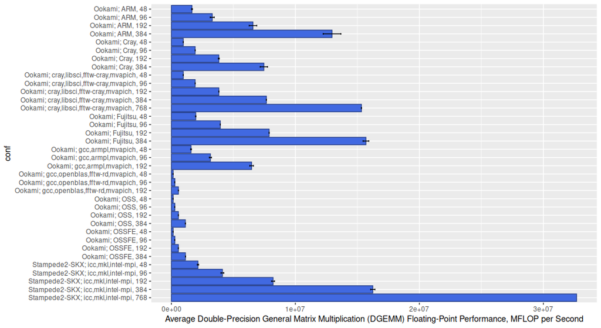

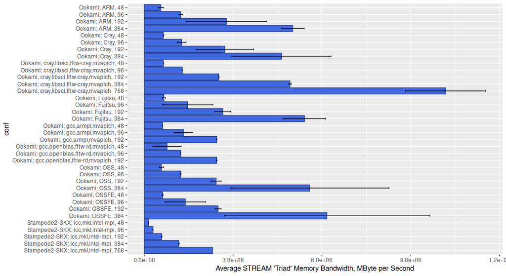

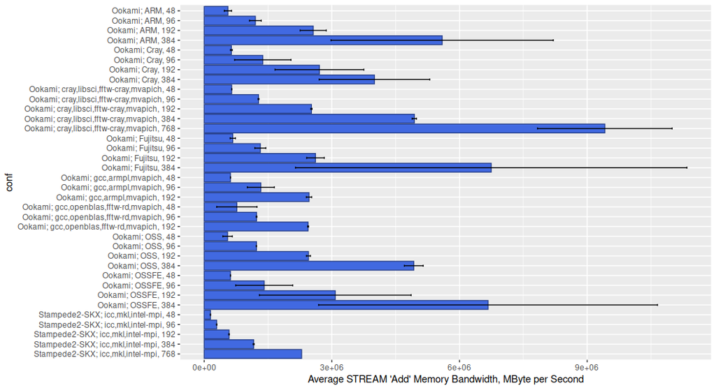

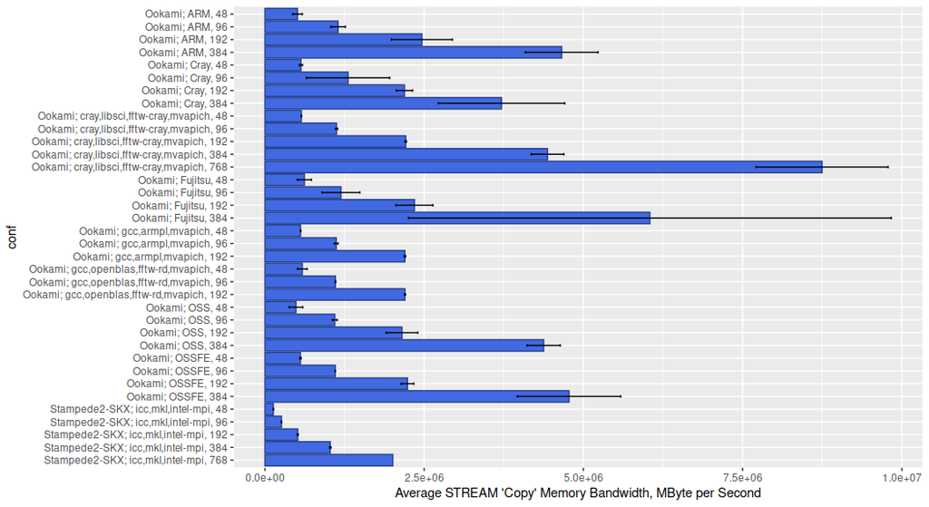

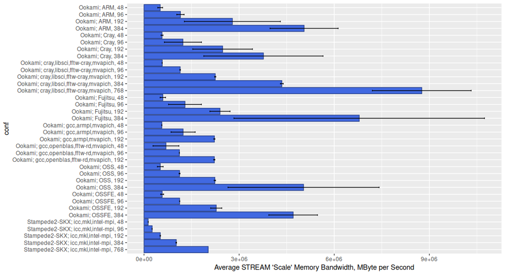

### Performance per Core (that is MPI Process)